# Machine Learning Engineer Nanodegree

## Project: Build a Digit Recognition Program

In this notebook, a template is provided for you to implement your functionality in stages which is required to successfully complete this project. If additional code is required that cannot be included in the notebook, be sure that the Python code is successfully imported and included in your submission, if necessary. Sections that begin with **'Implementation'** in the header indicate where you should begin your implementation for your project. Note that some sections of implementation are optional, and will be marked with **'Optional'** in the header.

In addition to implementing code, there will be questions that you must answer which relate to the project and your implementation. Each section where you will answer a question is preceded by a **'Question'** header. Carefully read each question and provide thorough answers in the following text boxes that begin with **'Answer:'**. Your project submission will be evaluated based on your answers to each of the questions and the implementation you provide.

> **Note:** Code and Markdown cells can be executed using the **Shift + Enter** keyboard shortcut. In addition, Markdown cells can be edited by typically double-clicking the cell to enter edit mode.

## Step 1: Design and Test a Model Architecture

Design and implement a deep learning model that learns to recognize sequences of digits. Train the model using synthetic data generated by concatenating character images from [notMNIST](http://yaroslavvb.blogspot.com/2011/09/notmnist-dataset.html) or [MNIST](http://yann.lecun.com/exdb/mnist/). To produce a synthetic sequence of digits for testing, you can for example limit yourself to sequences up to five digits, and use five classifiers on top of your deep network. You would have to incorporate an additional ‘blank’ character to account for shorter number sequences.

There are various aspects to consider when thinking about this problem:

- Your model can be derived from a deep neural net or a convolutional network.
- You could experiment sharing or not the weights between the softmax classifiers.
- You can also use a recurrent network in your deep neural net to replace the classification layers and directly emit the sequence of digits one-at-a-time.

You can use **Keras** to implement your model. Read more at [keras.io](https://keras.io/).

Here is an example of a [published baseline model on this problem](http://static.googleusercontent.com/media/research.google.com/en//pubs/archive/42241.pdf). ([video](https://www.youtube.com/watch?v=vGPI_JvLoN0)). You are not expected to model your architecture precisely using this model nor get the same performance levels, but this is more to show an exampe of an approach used to solve this particular problem. We encourage you to try out different architectures for yourself and see what works best for you. Here is a useful [forum post](https://discussions.udacity.com/t/goodfellow-et-al-2013-architecture/202363) discussing the architecture as described in the paper and here is [another one](https://discussions.udacity.com/t/what-loss-function-to-use-for-multi-digit-svhn-training/176897) discussing the loss function.

### Implementation

Use the code cell (or multiple code cells, if necessary) to implement the first step of your project. Once you have completed your implementation and are satisfied with the results, be sure to thoroughly answer the questions that follow.

```python
#####################################################################
# Import MNIST dataset directly from keras
#####################################################################
# Import useful libraries
from keras.datasets import mnist
import numpy as np

# Reload modules
%load_ext autoreload
%autoreload 2

# Read training and testing data
(X_train, y_train), (X_test, y_test) = mnist.load_data()

# Merge the training and testing set as we do not use them as they are
X_train = np.vstack([X_train, X_test])
y_train = np.hstack([y_train, y_test])

# Get image height and width
img_height = X_train.shape[1]
img_width = X_train.shape[2]
```

```python
# Generate synthetic sequences
from data_utils_synthetic import generate_sequences

X_synt, y_synt, len_synt = generate_sequences(X_train, y_train, img_height, img_width,
                                    max_digits=5, n_synthetic = 150000, random_seed=2017)
```

```
Distribution of sequence length:  (array([1, 2, 3, 4, 5]), array([29910, 29927, 30088, 30090, 29985]))
```

```python
# Plot and save some examples of synthetic sequences generated
from data_utils_synthetic import save_ex_sequences
save_ex_sequences(X_synt, y_synt, len_synt, max_digits=5, num_display=2, figsize=(16,4))
```

```python
# Normalize and split synthetic data into a training and testing dataset
from data_utils_synthetic import normalize_split_data

X_train, X_test, y_train_ohe, y_test_ohe = normalize_split_data(X_synt, y_synt, img_height,
                                                                img_width,test_size=0.2,
                                                                max_digits=5, n_synthetic=150000,
                                                                random_seed=2017)
```

```python
# Import CNN architecture
from cnn_digit_recognition import cnn_digit
from keras.optimizers import Adam

model = cnn_digit(input_shape=(28, 140, 1), localization=False, add_dropout=False, prob_dropout=0.5)

model.compile(loss='categorical_crossentropy',
              optimizer=Adam(lr=0.001, beta_1=0.9, beta_2=0.999, epsilon=1e-08, decay=0.0),
              metrics=['accuracy'])

model.fit([X_train], [y_train_ohe[0], y_train_ohe[1], y_train_ohe[2], y_train_ohe[3], y_train_ohe[4]],
           validation_data=([X_test], [y_test_ohe[0], y_test_ohe[1], y_test_ohe[2], y_test_ohe[3],
            y_test_ohe[4]]), nb_epoch=5, batch_size=128, verbose=1)
```

```
Train on 120000 samples, validate on 30000 samples
```

```
<keras.callbacks.History at 0x7f85451646a0>
```

```python
# Save the model
model.save('conc_mnist_cnn.h5')
```

### Question 1

*What approach did you take in coming up with a solution to this problem?*

**Answer:**

For this assignment I have chosen to use a convolutional neural network, to preserve the 2D structure of the image. The model that I have chosen was inspired by Ian's Goodfellow paper on multidigit recognition though the size of the convolution filters and the hidden layers was smaller due to computational constraints. I have also chose not to share the weights between classifiers.

### Question 2

*What does your final architecture look like? (Type of model, layers, sizes, connectivity, etc.)*

**Answer:** The network that I've chosen was inspired from the convolutional neural network described in [[1]](http://static.googleusercontent.com/media/research.google.com/en//pubs/archive/42241.pdf).

#### The model architecture can be seen in the diagram below.

I have chosen to add zero padding to the input images and to the convolution layers so that they do not lose spatial dimension too fast. It seems that padding improves the performance of the model [[2]](http://cs231n.github.io/convolutional-networks/#layerpat).

[figure not shown]

### Question 3

*How did you train your model? How did you generate your synthetic dataset?* Include examples of images from the synthetic data you constructed.

**Answer:**

These are the results that I have obtained after training the network for 5 epochs:

| Data Type | First Digit Accuracy | Second Digit Accuracy | Third Digit Accuracy | Fourth Digit Accuracy | Fifth Digit Accuracy |
| --- | --- | --- | --- | --- | --- |
| Train | 99.57% | 99.57% | 99.66% | 99.68% | 99.77% |
| Test | 99.56% | 99.35% | 99.56% | 96.63% | 99.76% |

## Step 2: Train a Model on a Realistic Dataset

Once you have settled on a good architecture, you can train your model on real data. In particular, the [Street View House Numbers (SVHN)](http://ufldl.stanford.edu/housenumbers/) dataset is a good large-scale dataset collected from house numbers in Google Street View. Training on this more challenging dataset, where the digits are not neatly lined-up and have various skews, fonts and colors, likely means you have to do some hyperparameter exploration to perform well.

### Implementation

Use the code cell (or multiple code cells, if necessary) to implement the first step of your project. Once you have completed your implementation and are satisfied with the results, be sure to thoroughly answer the questions that follow.

```python
# Import useful libraries
import pandas as pd
import cv2
import os

# Import helpful functions created to process the data
from data_utils import gray_rescale
from data_utils import get_classification_targets

# Specify path training and testing files
path_train = 'SVHN/train'
path_test = 'SVHN/test'

# Read the training and testing bounding box information
path_bbox_train = os.path.join(path_train, 'digitStruct.json')
path_bbox_test = os.path.join(path_test, 'digitStruct.json')
bbox = {}
bbox['train'] = pd.read_json(path_bbox_train)
bbox['test'] = pd.read_json(path_bbox_test)

# Empty dictionary to hold the size of the train and test data
size = {}
size['train']= bbox['train'].shape[0]
size['test'] = bbox['test'].shape[0]

# Visualize the size ot the datasets
print('Number of images in the train dataset: ', size['train'])
print('Number of images in the test dataset: ', size['test'])
```

```
Number of images in the train dataset:  33402
Number of images in the test dataset:  13068
```

```python
#################################################################
# First approach: Use the entire image
#################################################################

# Transform images to grayscale and rescale them
input_data = {}
input_data['train'] = {}
input_data['test'] = {}

for i in range(size['train']):
    input_data['train'][i] = cv2.imread('SVHN/train/%d.png'  %(i+1))
for i in range(size['test']):
    input_data['test'][i] = cv2.imread('SVHN/test/%d.png'  %(i+1))

X = gray_rescale(input_data, size, rescaled_width=64, rescaled_height=64)

# Get classification labels
cl_targets, cl_ohe = get_classification_targets(bbox, size, max_digits=5, null_target=10)

# Import CNN architecture
from cnn_digit_recognition import cnn_digit
from keras.optimizers import Adam

model = cnn_digit(input_shape=(64, 64, 1), localization=False, add_dropout=False, prob_dropout=0.5)

model.compile(loss='categorical_crossentropy',
              optimizer=Adam(lr=0.001, beta_1=0.9, beta_2=0.999, epsilon=1e-08, decay=0.0))

# Train the model
model.fit([X['train']], [cl_ohe['train'][0], cl_ohe['train'][1], cl_ohe['train'][2],
                         cl_ohe['train'][3], cl_ohe['train'][4]],
          nb_epoch=25, batch_size=132, verbose=0)

# Save the parameters of the network
model.save('classification_svhn_entire_image.h5')
```

```python
#####################################################################
# Evaluate performance of the model
#####################################################################
from data_utils import evaluate_performance

order_digits = ['First', 'Second', 'Third', 'Fourth', 'Fifth']

evaluate_performance(model, X, order_digits, cl_targets, size, data_type='train', max_digits=5)
evaluate_performance(model, X, order_digits, cl_targets, size, data_type='test', max_digits=5)
```

```
First digit average accuracy on the entire train dataset:  98.98 %
Second digit average accuracy on the entire train dataset:  98.86 %
Third digit average accuracy on the entire train dataset:  99.25 %
Fourth digit average accuracy on the entire train dataset:  99.7 %
Fifth digit average accuracy on the entire train dataset:  99.99 %
Average accuracy for the entire number on the train dataset 96.93 %

First digit average accuracy on the entire test dataset:  61.85 %
Second digit average accuracy on the entire test dataset:  55.61 %
Third digit average accuracy on the entire test dataset:  83.18 %
Fourth digit average accuracy on the entire test dataset:  98.83 %
Fifth digit average accuracy on the entire test dataset:  99.99 %
Average accuracy for the entire number on the test dataset 41.2 %
```

```python
####################################################################
# Second approach: Use the cropped image
####################################################################
# Import function to crop digits according to their bounding box
from data_utils import crop_digits

# Crop the images in both training and testing datasets
recalibrated_bbox, input_data = crop_digits(bbox, size, extra_margin=0.15,
                                            recalibrate_bounding_boxes=True)
X = gray_rescale(input_data, size, rescaled_width=64, rescaled_height=64)

model.fit([X['train']], [cl_ohe['train'][0], cl_ohe['train'][1], cl_ohe['train'][2],
                         cl_ohe['train'][3], cl_ohe['train'][4]],
          nb_epoch=25, batch_size=132, verbose=0)

model.save('classification_svhn_cropped_image.h5')
```

```python
###################################################################
# Evaluate performance second approach
###################################################################
evaluate_performance(model, X, order_digits, cl_targets, size, data_type='train', max_digits=5)
evaluate_performance(model, X, order_digits, cl_targets, size, data_type='test', max_digits=5)
```

```
First digit average accuracy on the entire train dataset:  99.1 %
Second digit average accuracy on the entire train dataset:  99.03 %
Third digit average accuracy on the entire train dataset:  99.16 %
Fourth digit average accuracy on the entire train dataset:  99.74 %
Fifth digit average accuracy on the entire train dataset:  99.99 %
Average accuracy for the entire number on the train dataset 97.17 %

First digit average accuracy on the entire test dataset:  91.23 %
Second digit average accuracy on the entire test dataset:  87.86 %
Third digit average accuracy on the entire test dataset:  93.63 %
Fourth digit average accuracy on the entire test dataset:  99.22 %
Fifth digit average accuracy on the entire test dataset:  99.99 %
Average accuracy for the entire number on the test dataset 78.04 %
```

```python
####################################################################
# Third approach: Add dropout with a probability of 0.5 after the
# first fully connected layer
####################################################################
model = cnn_digit(input_shape=(64, 64, 1), localization=False,
                  add_dropout=True, prob_dropout=0.5)

model.compile(loss='categorical_crossentropy',
              optimizer=Adam(lr=0.001, beta_1=0.9, beta_2=0.999, epsilon=1e-08, decay=0.0))

model.fit([X['train']], [cl_ohe['train'][0], cl_ohe['train'][1], cl_ohe['train'][2],
                         cl_ohe['train'][3], cl_ohe['train'][4]], nb_epoch=25, batch_size=132, verbose=0)

model.save('classification_svhn_cropped_image_dropout.h5')
```

```python
###################################################################
# Evaluate performance third approach
###################################################################
evaluate_performance(model, X, order_digits, cl_targets, size, data_type='train', max_digits=5)
evaluate_performance(model, X, order_digits, cl_targets, size, data_type='test', max_digits=5)
```

```
First digit average accuracy on the entire train dataset:  99.72 %
Second digit average accuracy on the entire train dataset:  99.53 %
Third digit average accuracy on the entire train dataset:  99.78 %
Fourth digit average accuracy on the entire train dataset:  99.92 %
Fifth digit average accuracy on the entire train dataset:  99.99 %
Average accuracy for the entire number on the train dataset 98.99 %

First digit average accuracy on the entire test dataset:  92.64 %
Second digit average accuracy on the entire test dataset:  90.14 %
Third digit average accuracy on the entire test dataset:  95.64 %
Fourth digit average accuracy on the entire test dataset:  99.33 %
Fifth digit average accuracy on the entire test dataset:  99.99 %
Average accuracy for the entire number on the test dataset 82.32 %
```

### Question 4

*Describe how you set up the training and testing data for your model. How does the model perform on a realistic dataset?*

**Answer:**

I have chose to use the [Street View House Numbers (SVHN)](http://ufldl.stanford.edu/housenumbers/) dataset to train and test my model on a realistic dataset. The 'train.tar.gz' dataset was used for training whilst the 'test.tar.gz' dataset was used for testing. I didn't use cross-validation as I believe it is too computationally expensive for deep learning applications. Here is the size of the datasets:

- Train dataset - 33402 images
- Test dataset - 13068 images

To process the 'digitStruct.mat' file in Python, I have used [this script](https://github.com/bvstillwell/udacity/blob/master/p5_deep/svhn_dataextract_tojson.py) which processes 'digitStruct.mat' and generates the '.json' version of it.

### Question 5

*What changes did you have to make, if any, to achieve "good" results? Were there any options you explored that made the results worse?*

**Answer:**

My first approach was to use the images as they were, without any cropping. This worked really well on the training dataset but performed extremely poorly on the test dataset achieving an accuracy of 41.2%.

My second approach was to crop the digits according to their bounding box information, keeping a margin of 15% on both axes. With this approach, the accuracy score on the test set grew to 78.04%. This was a significant increase but the difference between the train and test accuracy was still quite significant. This was a clear sign that the train dataset was overfitted.

To mitigate the risk of overfitting, I have decided to try a third approach which included a mask with a dropout probability of 0.5 just after the first fully connected layer. This indeed made the network generalize better to unseen data, obtaining a ~4% accuracy improvement on the test dataset.

### Question 6

*What were your initial and final results with testing on a realistic dataset? Do you believe your model is doing a good enough job at classifying numbers correctly?*

**Answer:**

The initial results were obtained using the entire image, without any cropping. Here are results obtained on the entire training and testing dataset.

| Data Type | First Digit Accuracy | Second Digit Accuracy | Third Digit Accuracy | Fourth Digit Accuracy | Fifth Digit Accuracy | Entire Number Accuracy |
| --- | --- | --- | --- | --- | --- | --- |
| Train | 98.98% | 98.86% | 99.25% | 99.7% | 99.99% | 96.93% |
| Test | 61.85% | 55.61% | 83.18% | 98.83% | 99.99% | 41.2% |

After cropping the images according to their bounding box information and added a dropout layer with p=0.5, I have managed to obtain the following results:

| Data Type | First Digit Accuracy | Second Digit Accuracy | Third Digit Accuracy | Fourth Digit Accuracy | Fifth Digit Accuracy | Entire Number Accuracy |
| --- | --- | --- | --- | --- | --- | --- |
| Train | 99.72% | 99.53% | 99.78% | 99.92% | 99.99% | 98.99% |
| Test | 92.64% | 90.14% | 95.64% | 99.33% | 99.99% | 82.32% |

I believe the model has a reasonable performance. I will train it for longer, once I insert the regression head for localization. Hopefully this would improve the performance on the test dataset.

## Step 3: Test a Model on Newly-Captured Images

Take several pictures of numbers that you find around you (at least five), and run them through your classifier on your computer to produce example results. Alternatively (optionally), you can try using OpenCV / SimpleCV / Pygame to capture live images from a webcam and run those through your classifier.

### Implementation

Use the code cell (or multiple code cells, if necessary) to implement the first step of your project. Once you have completed your implementation and are satisfied with the results, be sure to thoroughly answer the questions that follow.

```python
#############################################################
# Load the best model
#############################################################
from keras.models import load_model
model = load_model('classification_svhn_cropped_image_dropout.h5')

def predict_new_image(img_path, model, rescaled_width=64, rescaled_height=64, max_digits=5):
    img = cv2.imread(img_path)
    res = cv2.resize(img.mean(axis=2), (rescaled_height, rescaled_width),
                     interpolation = cv2.INTER_AREA).reshape(1,rescaled_height,rescaled_width,1)
    res = res/255
    y_pred = model.predict(res)
    y_pred = np.hstack([np.argmax(y_pred[i], axis=1).reshape(-1,1) for i in range(max_digits)])
    y_pred = y_pred[y_pred!=10]
    print('Model predicted: ', str(y_pred)[1:-1])
    plt.imshow(img)
    plt.show()
```

```
Model predicted:  6
```

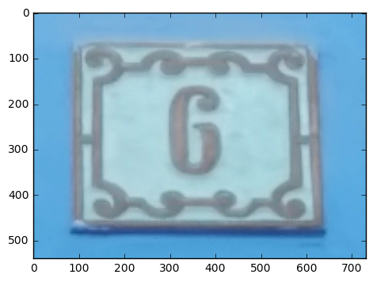

```
Model predicted:  1 2
```

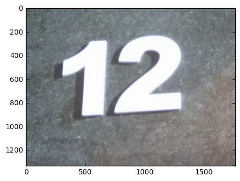

```
Model predicted:  4 4
```

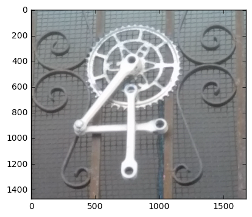

```
Model predicted:  3 4
```

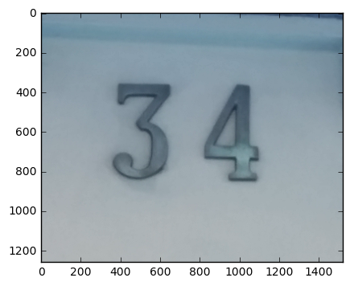

```
Model predicted:  1 5
```

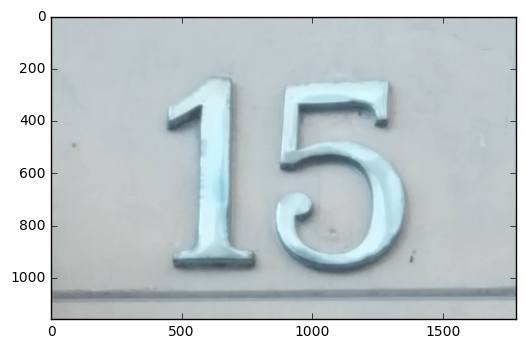

```python
path_images = os.listdir('new_images')
for img_path in path_images:
    predict_new_image('new_images/%s' %img_path, model,
                      rescaled_width=64, rescaled_height=64, max_digits=5)
```

### Question 7

*Choose five candidate images of numbers you took from around you and provide them in the report. Are there any particular qualities of the image(s) that might make classification difficult?*

**Answer:**

Above you can find 5 images of numbers that I took in Seville. I tried to find images as diverse as possible, with embelishments and noise around them to make this task a little bit more difficult.

### Question 8

*Is your model able to perform equally well on captured pictures or a live camera stream when compared to testing on the realistic dataset?*

**Answer:**

Yes, the model managed to predict accurately 4 out of 5 images. This gives us an accuracy of 80% which is close to the accuracy obtained on our testing dataset.

### Optional: Question 9

*If necessary, provide documentation for how an interface was built for your model to load and classify newly-acquired images.*

**Answer:**

### Step 4: Explore an Improvement for a Model

There are many things you can do once you have the basic classifier in place. One example would be to also localize where the numbers are on the image. The SVHN dataset provides bounding boxes that you can tune to train a localizer. Train a regression loss to the coordinates of the bounding box, and then test it.

### Implementation

Use the code cell (or multiple code cells, if necessary) to implement the first step of your project. Once you have completed your implementation and are satisfied with the results, be sure to thoroughly answer the questions that follow.

```python
# Load regression targets
from data_utils import get_regression_targets
reg_targets = get_regression_targets(input_data, size, recalibrated_bbox,
                                     left_null_digit=1.3, max_digits=5)

# Build cnn model with localization activated
model = cnn_digit(input_shape=(64, 64, 1), localization=True,
                  add_dropout=True, prob_dropout=0.5)

model.compile(loss={'first_softmax':'categorical_crossentropy',
                    'second_softmax':'categorical_crossentropy',
                    'third_softmax':'categorical_crossentropy',
                    'fourth_softmax':'categorical_crossentropy',
                    'fifth_softmax':'categorical_crossentropy',
                    'regression_head':'mean_squared_error'}
              ,optimizer=Adam(lr=0.001, beta_1=0.9, beta_2=0.999, epsilon=1e-08, decay=0.0))

model.fit([X['train']], [cl_ohe['train'][0], cl_ohe['train'][1], cl_ohe['train'][2],
          cl_ohe['train'][3], cl_ohe['train'][4], reg_targets['train']],
          nb_epoch=60, batch_size=132, verbose=0)

model.save('reg_class_model.h5')
```

```python
###################################################################
# Evaluate performance classification
###################################################################
evaluate_performance(model, X, order_digits, cl_targets, size, data_type='train', max_digits=5)
evaluate_performance(model, X, order_digits, cl_targets, size, data_type='test', max_digits=5)
```

```
First digit average accuracy on the entire train dataset:  99.92 %
Second digit average accuracy on the entire train dataset:  99.82 %
Third digit average accuracy on the entire train dataset:  99.93 %
Fourth digit average accuracy on the entire train dataset:  99.94 %
Fifth digit average accuracy on the entire train dataset:  100.0 %
Average accuracy for the entire number on the train dataset 99.61 %

First digit average accuracy on the entire test dataset:  92.42 %
Second digit average accuracy on the entire test dataset:  90.75 %
Third digit average accuracy on the entire test dataset:  95.63 %
Fourth digit average accuracy on the entire test dataset:  99.21 %
Fifth digit average accuracy on the entire test dataset:  99.99 %
Average accuracy for the entire number on the test dataset 83.06 %
```

```python
###########################################################################
# Evaluate regression performance using the Intersection over Union metric
# IoU computes the percentage of overlapping between the predicted and
# actual bounding boxes
###########################################################################
from data_utils import mean_iou

# Get predictions train and test dataset
y_pred = {}
y_pred['train'] = model.predict(X['train'])
y_pred['test'] = model.predict(X['test'])

# Compute IoU scores on the training and testing datasets
max_digits = 5
train_iou = np.zeros((reg_targets['train'].shape[0], max_digits))
test_iou = np.zeros((reg_targets['test'].shape[0], max_digits))
i = 0
for k in range(0, 20, 4):
    train_iou[:,i] = mean_iou(reg_targets['train'], y_pred['train'][5], k)
    test_iou[:,i] = mean_iou(reg_targets['test'], y_pred['test'][5], k)
    i += 1

# Compute the average IoU score on the entire training and testing dataset
print('Average IoU score on the train dataset: ', train_iou.mean())
print('Average IoU score on the test dataset: ', test_iou.mean())
```

```
Average IoU score on the train dataset:  0.817658513839
Average IoU score on the test dataset:  0.803222854445
```

```python
#########################################################################
# Plot predicted bounding boxes on the new images
#########################################################################
import matplotlib.pyplot as plt
def plot_bounding_box(img_path, model, rescaled_width=64, rescaled_height=64):
    img = cv2.imread(img_path)
    sample_size = img.shape
    res = cv2.resize(img.mean(axis=2), (rescaled_height, rescaled_width),
                     interpolation = cv2.INTER_LINEAR).reshape(1,rescaled_height,rescaled_width,1)
    res = res/255
    y_pred = model.predict(res)[5]
    for k in range(0, 20, 4):
        pred_tl = (int(y_pred[:,k]*sample_size[1]),
                   int(y_pred[:,k+1]*sample_size[0]))
        pred_br = (int(y_pred[:,k+2]*sample_size[1]),
                   int(y_pred[:,k+3]*sample_size[0]))
        pred_bound = cv2.rectangle(img, pred_tl, pred_br, (0,255,0), 10)
    plt.imshow(img)
    plt.show()
```

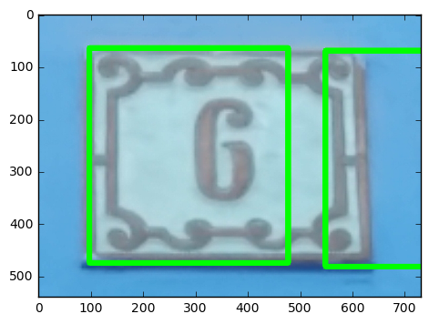

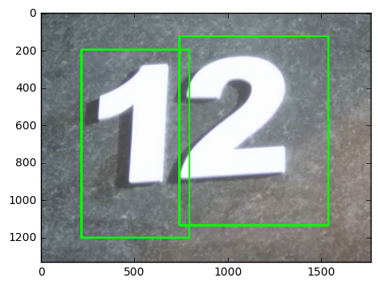

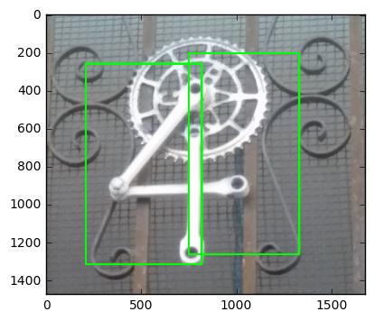

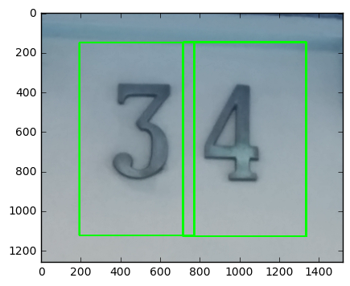

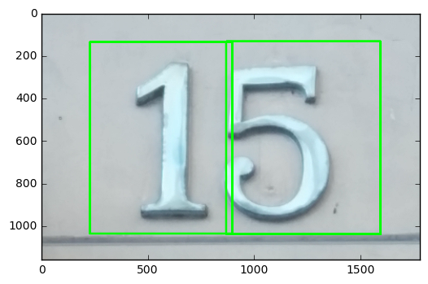

```python
path_images = os.listdir('new_images')
for img_path in path_images:
    plot_bounding_box('new_images/%s' %img_path, model, rescaled_width=64, rescaled_height=64)
```

### Question 10

*How well does your model localize numbers on the testing set from the realistic dataset? Do your classification results change at all with localization included?*

**Answer:**

To evaluate the performance of the bounding boxes localization, I have used the Intersection over Union (IoU) metric which computes the percentage of overlapping between the predicted and actual bounding boxes. The IoU obtained on the test dataset was 80.32%. I believe this score is quite high given that the cost function tried to optimize both classification and regression. If we would have used a separate CNN model and train it to solely optimize the bounding boxes the performance would be higher.

There was a slight improvement in the classification results but I believe this is merely due to the longer training time.

### Question 11

*Test the localization function on the images you captured in **Step 3**. Does the model accurately calculate a bounding box for the numbers in the images you found? If you did not use a graphical interface, you may need to investigate the bounding boxes by hand.* Provide an example of the localization created on a captured image.

**Answer:**

As you can see above, the model has been able to accurately calculate a bounding box for the digits in the second, fourth and fifth image.

The digits in the first and third image were a little bit more difficult to localize.

In the first image, the model manages to localize the digit 6 but fails to predict the bounding boxes of null digits outside the image. Since the model has accurately predicted '6' for that image, I believe the display can be optimized by showing the bounding boxes only of non-null digits.

The third image I believe was the most difficult as it had a lot of embelishments. Unfortunately the model fails to localize the digit in that image.

## Optional Step 5: Build an Application or Program for a Model

Take your project one step further. If you're interested, look to build an Android application or even a more robust Python program that can interface with input images and display the classified numbers and even the bounding boxes. You can for example try to build an augmented reality app by overlaying your answer on the image like the [Word Lens](https://en.wikipedia.org/wiki/Word_Lens) app does.

Loading a TensorFlow model into a camera app on Android is demonstrated in the [TensorFlow Android demo app](https://github.com/tensorflow/tensorflow/tree/master/tensorflow/examples/android), which you can simply modify.

If you decide to explore this optional route, be sure to document your interface and implementation, along with significant results you find. You can see the additional rubric items that you could be evaluated on by [following this link](https://review.udacity.com/#!/rubrics/413/view).

### Optional Implementation

Use the code cell (or multiple code cells, if necessary) to implement the first step of your project. Once you have completed your implementation and are satisfied with the results, be sure to thoroughly answer the questions that follow.

```python
# Import useful libraries
from keras.models import load_model
import numpy as np
import cv2

def recognize_digits_bbox(filename='first_video.m4v', save_as ='output'):
    # Specify font family for text
    font = cv2.FONT_HERSHEY_SIMPLEX
    # Load best model
    model = load_model('reg_class_model.h5')
    # Open video
    cap = cv2.VideoCapture(filename)
    # Get the width and height of the video
    height = int(cap.get(4))
    width = int(cap.get(3))
    # Define the codec and create VideoWriter object
    fourcc = cv2.VideoWriter_fourcc(*'XVID')
    output = cv2.VideoWriter(save_as + '_classified.avi', fourcc, 20.0, (width,height))
    while(cap.isOpened()):
        ret, frame = cap.read()
        gray_frame = frame.mean(axis=2)
        res = cv2.resize(gray_frame, (64,64),
                interpolation = cv2.INTER_AREA).reshape(1,64,64,1)
        res = res/255
        y_pred = model.predict(res)
        num_pred = np.hstack(
                    [np.argmax(y_pred[i], axis=1).reshape(-1,1) for i in range(5)])
        num_pred = num_pred[num_pred!=10]
        for k in range(0, 20, 4):
            pred_tl = (int(y_pred[5][:,k]*width),
                       int(y_pred[5][:,k+1]*height))
            pred_br = (int(y_pred[5][:,k+2]*width),
                       int(y_pred[5][:,k+3]*height))
            pred_bound = cv2.rectangle(frame, pred_tl, pred_br, (0,255,0), 5)
        cv2.putText(frame, str(num_pred)[1:-1], (10,100), font, 4, (255,255,255))
        cv2.imshow('frame',frame)
        output.write(frame)
        if cv2.waitKey(1) & 0xFF == ord('q'):
            break

    cap.release()
    cv2.destroyAllWindows()
```

```python
from IPython.display import YouTubeVideo
YouTubeVideo('t_2mRPF9hC4')
```

[video not shown]

```python
from IPython.display import YouTubeVideo
YouTubeVideo('dJwT4ZfqXgI')
```

[video not shown]

### Documentation

Provide additional documentation sufficient for detailing the implementation of the Android application or Python program for visualizing the classification of numbers in images. It should be clear how the program or application works. Demonstrations should be provided.

Inspired by the example provided in the OpenCv documentation on [how to capture a video](http://docs.opencv.org/3.0-beta/doc/py_tutorials/py_gui/py_video_display/py_video_display.html), I have created a function which takes the name of the video and the output as arguments. The function processes each frame of the video and passes it through our model to obtain digit predictions and bounding boxes localization. I have inserted above two sample videos that were obtained after using this function.

If I pass the filename as 0, the function will use the webcam to recognize and localize in real-time digits.

> **Note**: Once you have completed all of the code implementations and successfully answered each question above, you may finalize your work by exporting the iPython Notebook as an HTML document. You can do this by using the menu above and navigating to  
> **File -> Download as -> HTML (.html)**. Include the finished document along with this notebook as your submission.